# Indel Signature InsDel2b

# InsDel2b

(corresponds to 83-type signature C_ID2)

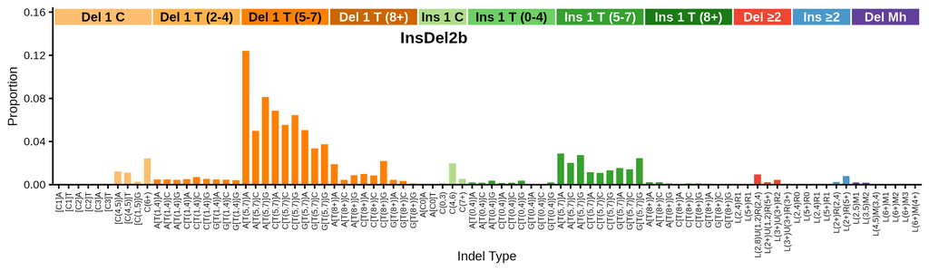

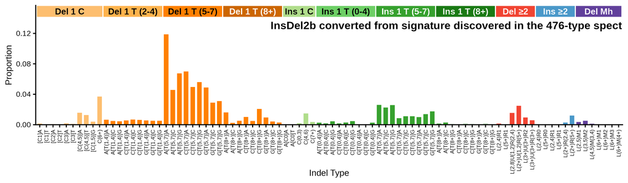

89-type spectrum of the linking tumor SP96118 | cosine similarity to InsDel2b: 0.9645

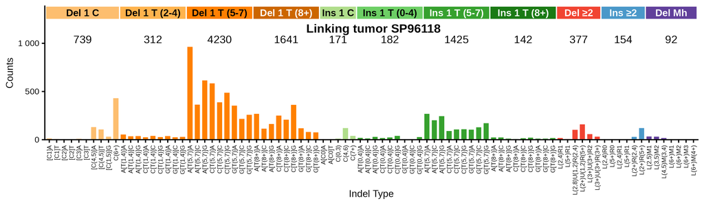

**Click to view decomposition of the linking tumor spectrum**

Partial mutation signature of SP96118 due to InsDel2b

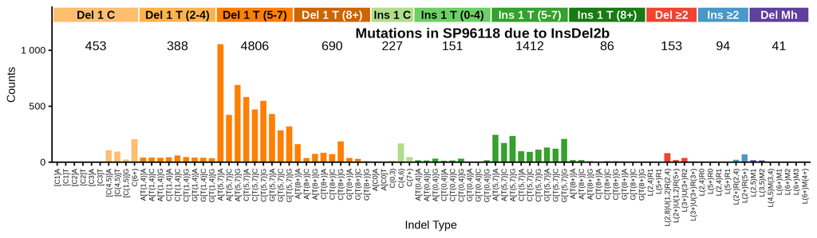

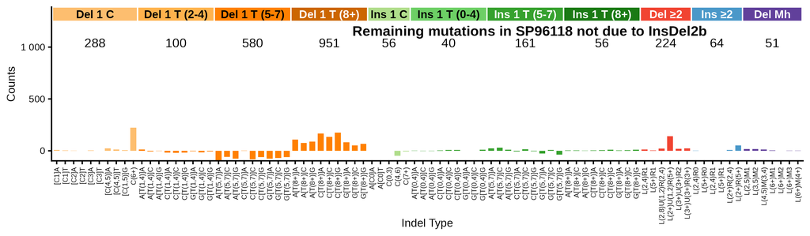

Max neg fraction (maximum allowed negative residual count as fraction of total): 0.09  
N subtract (mutation count assigned to signature): 8501.4  
N residual (mutation count in residual “partial spectrum”): 963.6  
Total negative (sum of negative residual mutation counts): 804.3  
N negative channels (number of channels with negative residual): 31  
P(≥ total negative) (Monte Carlo estimated probability that negative-binomial-sampled spectra from the signature contributing N subtract mutations would produce a total negative count >= the observed Total negative; higher number means not surprising): 0.610

**Per-channel residual breakdown**

| Channel | Spectrum | Sig_Count | Residual | Sig_Prop |
| --- | --- | --- | --- | --- |
| [Del(C):R1]A | 13 | 4.0 | 9 | 0.00047 |
| [Del(C):R1]T | 7 | 2.2 | 4.8 | 0.00026 |
| [Del(C):R2]A | 5 | 3.7 | 1.3 | 0.00043 |
| [Del(C):R2]T | 1 | 2.2 | -1.2 | 0.00026 |
| [Del(C):R3]A | 10 | 5.6 | 4.4 | 0.00066 |
| [Del(C):R3]T | 5 | 4.9 | 0.1 | 0.00058 |
| [Del(C):R(4,5)]A | 130 | 105.4 | 24.6 | 0.01240 |
| [Del(C):R(4,5)]T | 107 | 94.9 | 12.1 | 0.01117 |
| [Del(C):R(1,5)]G | 31 | 23.6 | 7.4 | 0.00278 |
| Del(C):R(6,9) | 430 | 206.5 | 223.5 | 0.02429 |
| A[Del(T):R(1,4)]A | 54 | 41.6 | 12.4 | 0.00489 |
| A[Del(T):R(1,4)]C | 35 | 40.9 | -5.9 | 0.00482 |
| A[Del(T):R(1,4)]G | 37 | 38.6 | -1.6 | 0.00454 |
| C[Del(T):R(1,4)]A | 26 | 44.5 | -18.5 | 0.00523 |
| C[Del(T):R(1,4)]C | 40 | 59.4 | -19.4 | 0.00699 |
| C[Del(T):R(1,4)]G | 28 | 46.0 | -18 | 0.00541 |
| G[Del(T):R(1,4)]A | 38 | 42.5 | -4.5 | 0.00500 |
| G[Del(T):R(1,4)]C | 25 | 39.4 | -14.4 | 0.00463 |
| G[Del(T):R(1,4)]G | 29 | 34.7 | -5.7 | 0.00408 |
| A[Del(T):R(5,7)]A | 963 | 1055.0 | -92 | 0.12410 |
| A[Del(T):R(5,7)]C | 364 | 423.5 | -59.5 | 0.04981 |
| A[Del(T):R(5,7)]G | 614 | 690.6 | -76.6 | 0.08123 |
| C[Del(T):R(5,7)]A | 585 | 583.1 | 1.9 | 0.06859 |
| C[Del(T):R(5,7)]C | 389 | 470.7 | -81.7 | 0.05537 |
| C[Del(T):R(5,7)]G | 488 | 548.1 | -60.1 | 0.06447 |
| G[Del(T):R(5,7)]A | 354 | 430.7 | -76.7 | 0.05067 |
| G[Del(T):R(5,7)]C | 215 | 285.4 | -70.4 | 0.03357 |
| G[Del(T):R(5,7)]G | 258 | 319.1 | -61.1 | 0.03753 |
| A[Del(T):R(8,)]A | 268 | 160.8 | 107.2 | 0.01892 |
| A[Del(T):R(8,)]C | 114 | 37.7 | 76.3 | 0.00444 |

[output cut: 59 more lines]

## 476-type representations corresponding to InsDel2b

Extracted 476-type signature corresponding to InsDel2b

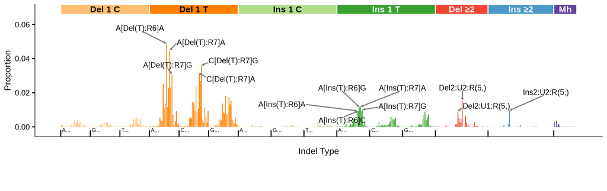

476-type spectrum of the linking tumor SP96118; cosine similarity to the extracted 476-type signature is 0.9659

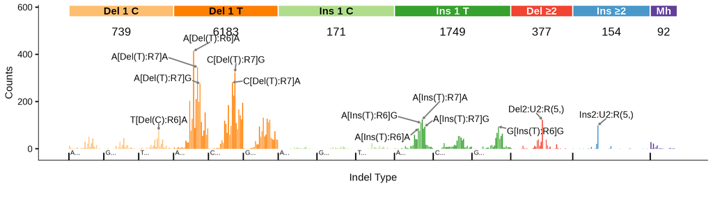

## 83-type signature corresponding to InsDel2b (C_ID2)

**Note**

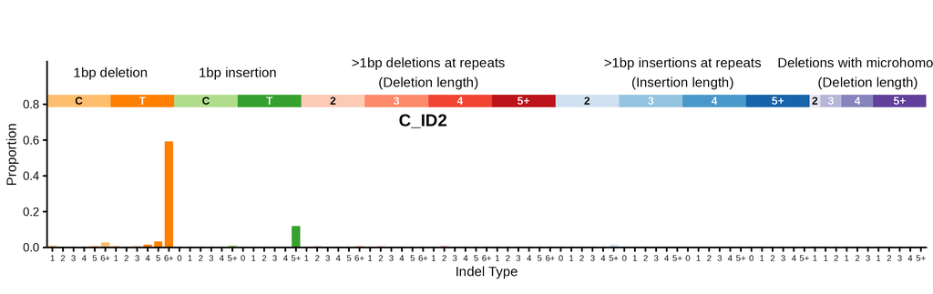

**Click here to see with insertions and deletions of T in long poly-T suppressed**

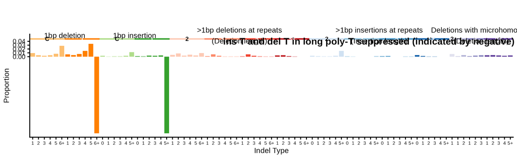

83-type signature converted from signature discovered in the 476-type spectra (using bipartite matching optimization) | cosine similarity to C_ID2: 0.9751

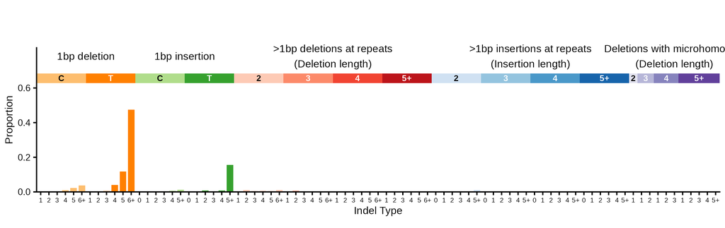

**Click here to see with insertions and deletions of T in long poly-T suppressed**

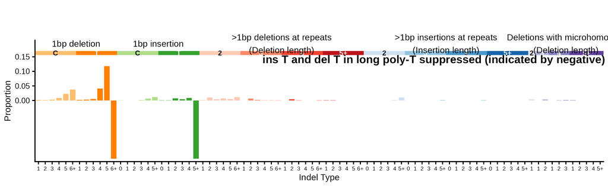

**Click to see flow diagrams: 476-type to 83-type collapse**

These Sankey diagrams show how the 476-type mutation categories are redistributed to 83-type categories using bipartite matching. We only show the diagrams for insertions or deletions of > 1 base because it is for these indels that 476-type categories map to > 1 83-type category.

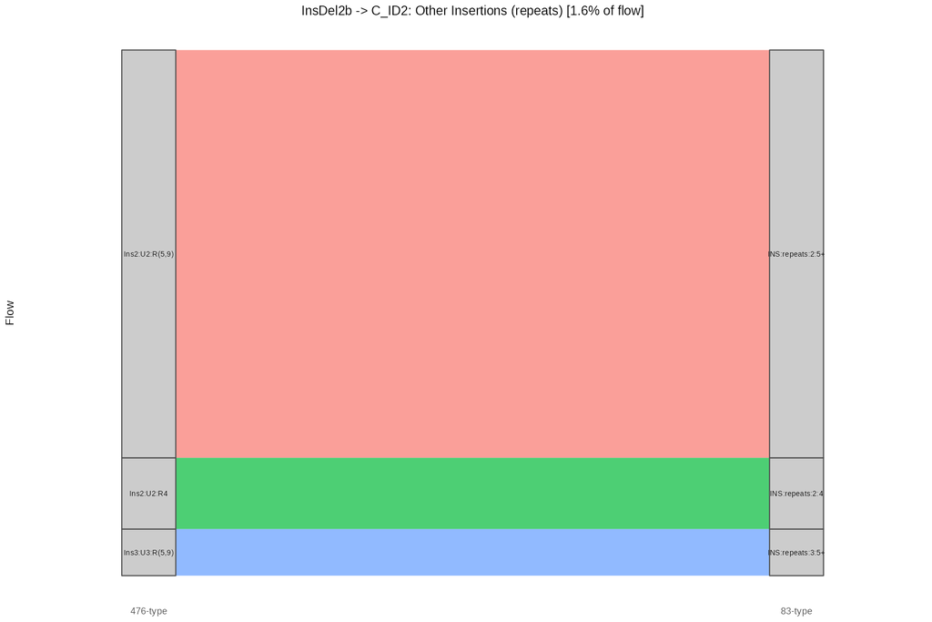

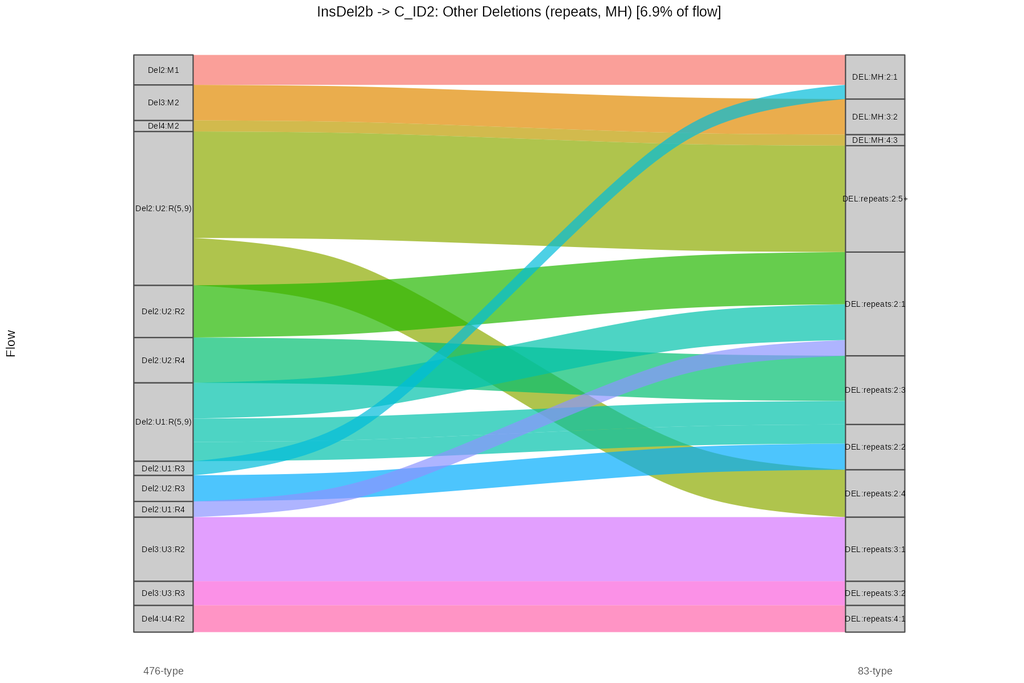

83-type spectrum of the linking tumor SP96118 | cosine similarity to C_ID2: 0.9857

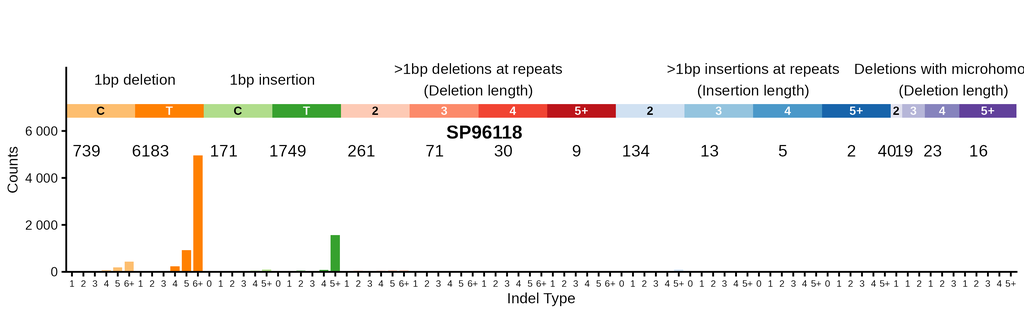

**Click here to see with insertions and deletions of T in long poly-T suppressed**

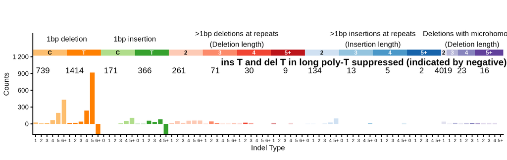

83-type spectrum of best 83-type matching tumor DRUP01080031T | cosine similarity to C_ID2: 0.9996

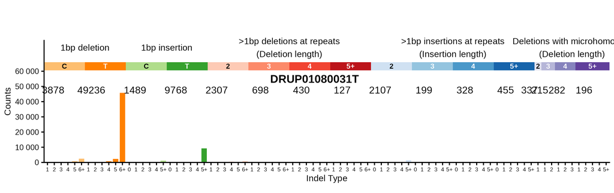

**Click here to see with insertions and deletions of T in long poly-T suppressed**

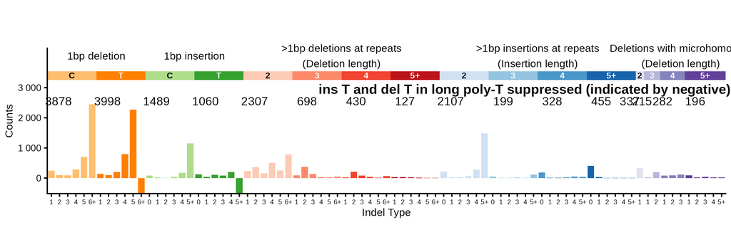

### Similar COSMIC signatures

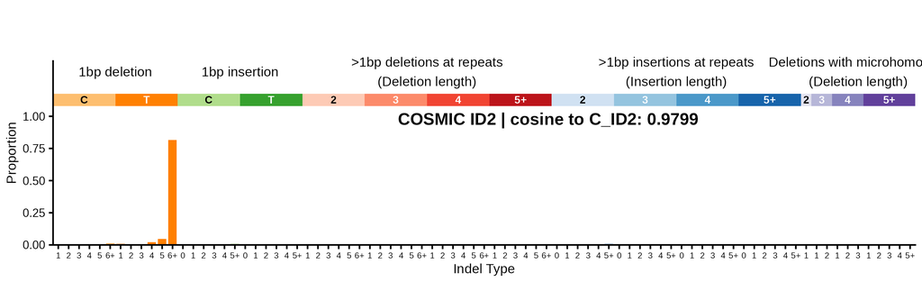

**Click here to see with insertions and deletions of T in long poly-T suppressed**

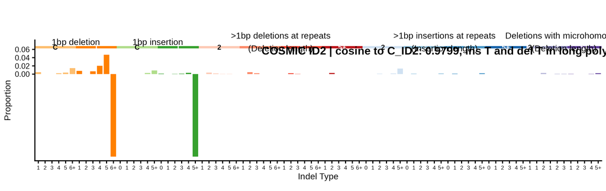

### Similar signatures from Jin et al. 2024

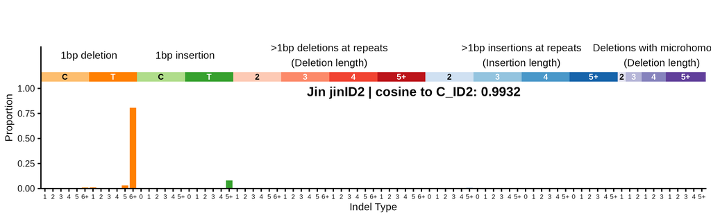

**Click here to see with insertions and deletions of T in long poly-T suppressed**

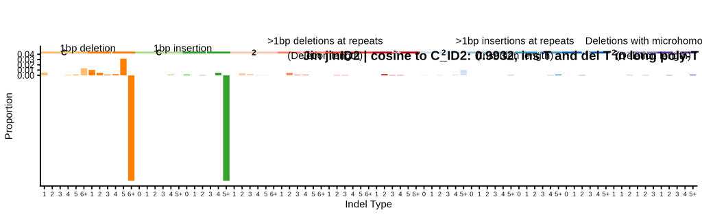